# Exploring the BRFSS data

## Setup

### Load packages

```r
library(ggplot2)
library(dplyr)
```

### Load data

Make sure your data and R Markdown files are in the same directory. When loaded your data file will be called `brfss2013`. Delete this note when before you submit your work.

```r
load("brfss2013.RData")
```

Student name: Jason Zhang | Week 5 - Integrated Data Analysis Project | May-15-2020

Objective: The objective of this project is to investigate the data from BRFSS2013 Survey to perform analysis on the given data.

## Part 1: Data

The structure of given data can be retreived using `dim()` command. The command returns to corresponding rows and columns of the given data.

```r
dim(brfss2013)
```

```
## [1] 491775    330
```

The `brfss2013.RData` is a dataframe with 491,775 observations for 330 variables. However, not all the observations are valuable, one needs to investigate the data and find out the valuable inforamtion for analysis.

## Part 2: Research questions

**Research quesion 1:** What are potential factors that are asscoiated with behavioral risk factors for the non-institutionalized adult population residing in the US.

**Research quesion 2:** How often people do routine checkup with insuranced covered or not geographically?

**Research quesion 3:** Are there any association of education level to the income between male and female?

## Part 3: Exploratory data analysis

NOTE: Insert code chunks as needed by clicking on the “Insert a new code chunk” button (green button with orange arrow) above. Make sure that your code is visible in the project you submit. Delete this note when before you submit your work.

**Research quesion 1:** How does the smoking behavor impact length of sleep for both males and females?

```r
aa<-select(brfss2013,sleptim1,smokday2,sex)%>%filter(!is.na(sleptim1),!is.na(smokday2),!is.na(sex))
```

Select target parameters for summary

```r
aa%>%group_by(sleptim1,smokday2,sex)%>%summarize(count=n())
```

```
## # A tibble: 128 x 4
## # Groups:   sleptim1, smokday2 [68]
##    sleptim1 smokday2   sex    count
##       <int> <fct>      <fct>  <int>
##  1        1 Every day  Male      19
##  2        1 Every day  Female    26
##  3        1 Some days  Male       9
##  4        1 Some days  Female    11
##  5        1 Not at all Male      21
##  6        1 Not at all Female    18
##  7        2 Every day  Male     152
##  8        2 Every day  Female   134
##  9        2 Some days  Male      48
## 10        2 Some days  Female    56
## # ... with 118 more rows
```

Table of summary is shown for people with different somking behavoir ranked by their length of sleep.

It might be fishy by looking at the summary of length of sleep. There some observations showing that 1 hour or 24 hour of sleep during the day were selected by some people. It is necessary to look for basic stats of people sleep time to see if the whole survey is believable.

```r
aa %>% select(sleptim1)%>%summarise(mean_dd = mean(sleptim1), sd_dd = sd(sleptim1), n = n())
```

```
##    mean_dd    sd_dd      n
## 1 7.002699 1.555424 211582
```

The basic states show that the median of the length of sleep time for over 210,000 observations is ~7 hours with standard deviation of 1.56. Which the results are resaonable.

The next step to plot to investigate whether people with different somking behavior have different sleep time during the day.

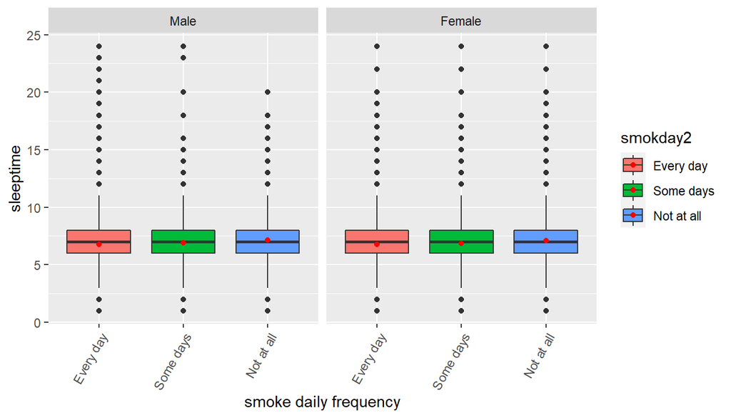

```r
ggplot(data=aa,aes(x= smokday2,y=sleptim1,fill=smokday2))+ geom_boxplot() + theme(axis.text.x = element_text(angle = 60,vjust=1,hjust=1))+facet_grid(.~sex) + xlab("smoke daily frequency")+ylab("sleeptime")+stat_summary(fun.y = mean,color = "red",geom = "point")
```

It seems like the smoking behavior has no significane impact on length of sleep for both males and females. The boxplot shows silmilar median for both males and females at different frequency of smoking during the day.The color to distinguish people with different somking behavior.Mean value for each category has been identified by the red dot on the each boxes.

**Research quesion 2:** How often people do routine checkup with insuranced covered or not geographically?

The first step is to filter the BRFSS2013 data to get rid of NA observations.

```r
#What is the count for people with different education level
bb<-select(brfss2013,hlthpln1,checkup1,X_state)%>%filter(!is.na(hlthpln1),!is.na(checkup1),!is.na(X_state),X_state!=0)
```

After filtering the survey, there are 483,731 observations. Now we look at summary of all three variables by their separate frequency of each variable

```r
#Summary of three variables by frequency
bb%>%summary()
```

```
##  hlthpln1                    checkup1               X_state
##  Yes:429488   Within past year   :355076   Florida      : 33127
##  No : 54243   Within past 2 years: 57043   Kansas       : 22792
##               Within past 5 years: 33536   Nebraska     : 16849
##               5 or more years ago: 33590   Massachusetts: 14917
##               Never              :  4486   Minnesota    : 14145
##                                            New Jersey   : 13524
##                                            (Other)      :368377
```

For checkups

The percentage and counts of frequency people doing checups is shown as follow

```r
 summarise(group_by(bb,checkup1), count=n(), per_col=count/nrow(bb)*100)
```

```
## # A tibble: 5 x 3
##   checkup1             count per_col
##   <fct>                <int>   <dbl>
## 1 Within past year    355076  73.4
## 2 Within past 2 years  57043  11.8
## 3 Within past 5 years  33536   6.93
## 4 5 or more years ago  33590   6.94
## 5 Never                 4486   0.927
```

figure is shown as follow

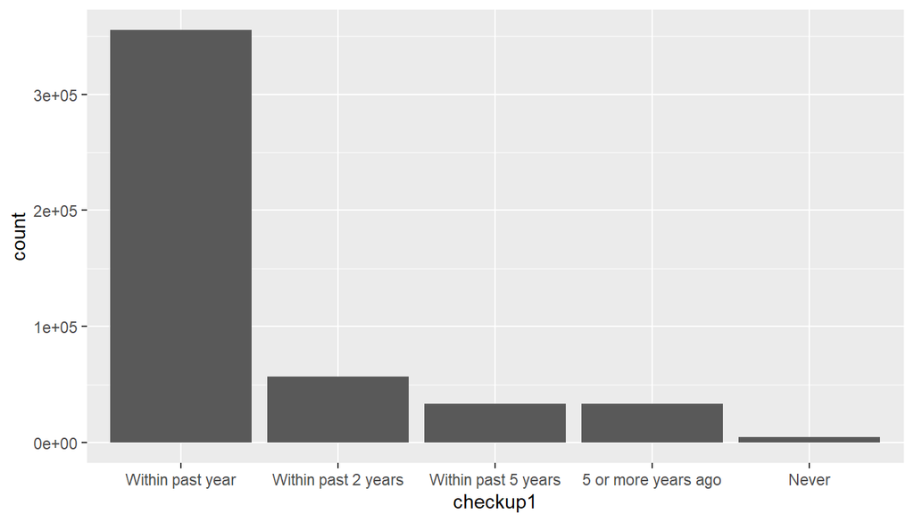

```r
ggplot(bb,aes(x=checkup1))+geom_bar()
```

Which states are people who took the survey at.

The distribution is shown as follow

```r
 summarise(group_by(bb,X_state), count=n(), per_col=count/nrow(bb)*100)
```

```
## # A tibble: 53 x 3
##    X_state              count per_col
##    <fct>                <int>   <dbl>
##  1 Alabama               6373   1.32
##  2 Alaska                4508   0.932
##  3 Arizona               4175   0.863
##  4 Arkansas              5145   1.06
##  5 California           11444   2.37
##  6 Colorado             13382   2.77
##  7 Connecticut           7649   1.58
##  8 Delaware              5141   1.06
##  9 District of Columbia  4877   1.01
## 10 Florida              33127   6.85
## # ... with 43 more rows
```

figure is shown as follow

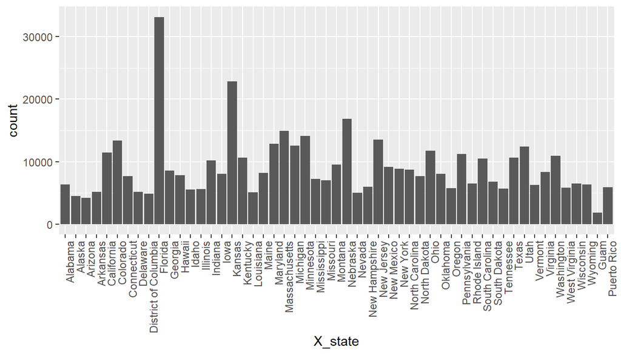

```r
ggplot(bb,aes(x=X_state))+geom_bar()+theme(axis.text.x = element_text(angle = 90,vjust=1,hjust=1))
```

The summary of people covered by insurance or not.

```r
 summarise(group_by(bb,hlthpln1), count=n(), per_col=count/nrow(bb)*100)
```

```
## # A tibble: 2 x 3
##   hlthpln1  count per_col
##   <fct>     <int>   <dbl>
## 1 Yes      429488    88.8
## 2 No        54243    11.2
```

figure is shown as follow

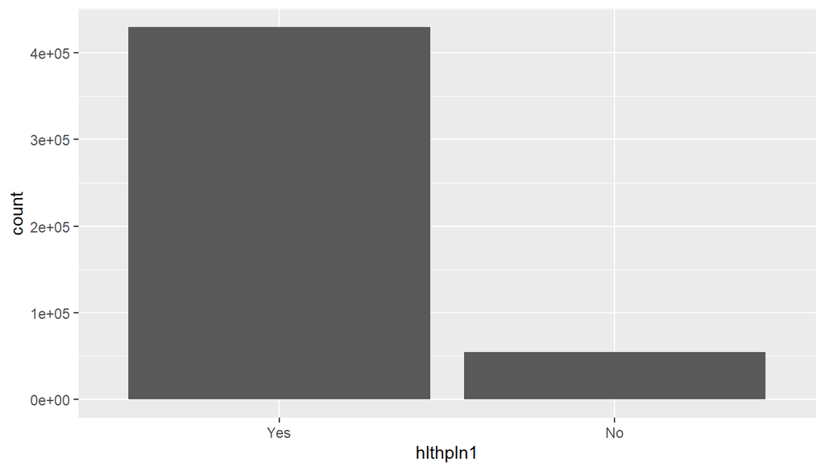

```r
ggplot(bb,aes(x=hlthpln1))+geom_bar()
```

To sum up, invesigate frequency by states and whether covered by insurances

```r
#People with insurence
summarize(group_by(bb,hlthpln1,checkup1,X_state)%>%filter(hlthpln1 == "Yes"),count=n(),per_col= count/nrow(bb)*100)%>%arrange(desc(per_col))
```

```
## # A tibble: 265 x 5
## # Groups:   hlthpln1, checkup1 [5]
##    hlthpln1 checkup1         X_state       count per_col
##    <fct>    <fct>            <fct>         <int>   <dbl>
##  1 Yes      Within past year Florida       23480    4.85
##  2 Yes      Within past year Kansas        16018    3.31
##  3 Yes      Within past year Massachusetts 11853    2.45
##  4 Yes      Within past year Nebraska      10585    2.19
##  5 Yes      Within past year Minnesota      9973    2.06
##  6 Yes      Within past year Maryland       9919    2.05
##  7 Yes      Within past year New Jersey     9601    1.98
##  8 Yes      Within past year Michigan       8814    1.82
##  9 Yes      Within past year Ohio           8310    1.72
## 10 Yes      Within past year Colorado       8239    1.70
## # ... with 255 more rows
```

```r
#People without insurence
summarize(group_by(bb,hlthpln1,checkup1,X_state)%>%filter(hlthpln1 == "No"),count=n(),per_col= count/nrow(bb)*100)%>%arrange(desc(per_col))
```

```
## # A tibble: 265 x 5
## # Groups:   hlthpln1, checkup1 [5]
##    hlthpln1 checkup1            X_state        count per_col
##    <fct>    <fct>               <fct>          <int>   <dbl>
##  1 No       Within past year    Florida         2076   0.429
##  2 No       Within past year    Kansas          1153   0.238
##  3 No       5 or more years ago Florida         1110   0.229
##  4 No       Within past year    Texas            983   0.203
##  5 No       Within past year    New Jersey       834   0.172
##  6 No       Within past 2 years Florida          779   0.161
##  7 No       Within past 5 years Florida          701   0.145
##  8 No       Within past year    Georgia          668   0.138
##  9 No       Within past year    North Carolina   622   0.129
## 10 No       Within past year    Kentucky         608   0.126
## # ... with 255 more rows
```

According to the BRFSS 2013 survey, there are 88.79% participants had insurance plan while 11.21% not. for the past year, Florida has both highest count of people that have/not have insurance and did routine checkup. The percentage are 4.85% and 0.429% repectively.

**Research quesion 3:** The purpose of this research is to investigate the association of education level to the income between male and female.

The first step is to locate three parameters are investigated are `educa`,`income2`,`sex`.The whole data frame `brfss2013`is renamed to `cc` and trimed using `!is.na` to eliminate`NA`observations.

```r
cc<-select(brfss2013,educa,income2,sex)%>%filter(!is.na(educa),!is.na(income2),!is.na(sex))
```

The new trimed data frame with valid counts can be summarized as follow

```r
cc%>% group_by(educa,income2,sex)%>%summarize(count=n())
```

```
## # A tibble: 96 x 4
## # Groups:   educa, income2 [48]
##    educa                                      income2           sex    count
##    <fct>                                      <fct>             <fct>  <int>
##  1 Never attended school or only kindergarten Less than $10,000 Male      32
##  2 Never attended school or only kindergarten Less than $10,000 Female    89
##  3 Never attended school or only kindergarten Less than $15,000 Male      39
##  4 Never attended school or only kindergarten Less than $15,000 Female    34
##  5 Never attended school or only kindergarten Less than $20,000 Male      44
##  6 Never attended school or only kindergarten Less than $20,000 Female    34
##  7 Never attended school or only kindergarten Less than $25,000 Male      30
##  8 Never attended school or only kindergarten Less than $25,000 Female    20
##  9 Never attended school or only kindergarten Less than $35,000 Male      24
## 10 Never attended school or only kindergarten Less than $35,000 Female    28
## # ... with 86 more rows
```

Then the association of `educa`and`income2` between sex can be ploted using `ggplot` based on the count number.

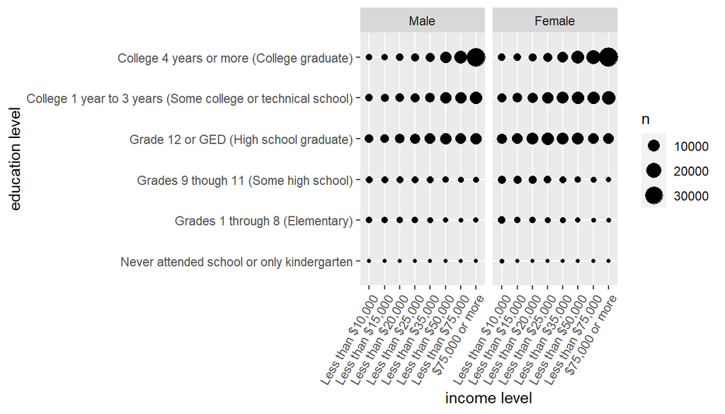

```r
ggplot(data=cc,aes(x = income2,y=educa))+ geom_count() + theme(axis.text.x = element_text(angle = 60,vjust=1,hjust=1))+facet_grid(.~sex) + xlab("income level")+ylab("education level")
```

A interesting phenomenone is show based on the plot shown above. Regardless of male or female, one tends to have higher income abover $75,000 with educational level above grade 12 or GED. While reverse trend is observed on ones with education level below grade 12 or GED. With people who have grade 12 or GED, more females are in the range of from less than $10,000 to less than $25,000 while males have slightly higher income above $25,000 based on the survey.